# Group1_Final_Project_Part3

```python
import numpy as np
import matplotlib.pyplot as plt
import pandas as pd
import datetime
import ipywidgets as widgets
import altair as alt

# modify to your location
df = pd.read_csv('Monthly_Treasury_Statement.csv')
df = df.fillna(0)
df['Record Date'] = pd.to_datetime(df['Record Date'])
```

### Understanding Financial Trends Visualization

This interactive visualization illustrates financial trends over time based on different expenditure categories.

#### Tips:

Enjoy exploring financial trends and gaining insights into expenditure patterns over time!

```python
# Convert 'Record Date' to datetime
df['Record Date'] = pd.to_datetime(df['Record Date'])

# Group by 'Classification Description' and calculate the sum of amounts for each description over all time
grouped = df.groupby('Classification Description')['Current Month Receipt or Outlay Amount'].sum().reset_index()

# Find the top 10 classifications based on total amount over all time
top_10_all_time = grouped.nlargest(10, 'Current Month Receipt or Outlay Amount')

# Filter the original DataFrame for the top 10 classifications
filtered_df = df[df['Classification Description'].isin(top_10_all_time['Classification Description'])]

# Altair plot to visualize the top 10 classifications over time
selection = alt.selection_single(fields=['Classification Description'], empty='all')
color = alt.condition(selection, alt.Color('Classification Description:N', legend=None), alt.value('lightgray'))

chart = alt.Chart(filtered_df).mark_line().encode(
    x='Record Date:T',
    y='Current Month Receipt or Outlay Amount:Q',
    color=color,
    tooltip=['Classification Description:N', 'Record Date:T', 'Current Month Receipt or Outlay Amount:Q']
).add_selection(selection)

# Add circles for each data point
circles = chart.mark_circle().encode(
    x='Record Date:T',
    y='Current Month Receipt or Outlay Amount:Q',
    color=color
).transform_filter(selection)

chart = chart + circles

chart = chart.properties(
    width=800,
    height=400,
    title='Top 10 Classification Descriptions over Time for All Time'
).interactive()

chart
```

[output not shown]

[interactive chart not shown]

### Financial Trends Interactive Visualization

This visualization allows users to explore financial trends over different expenditure categories across various time periods.

#### How to Use:

1. **Selecting Categories:**
   - Use the dropdown menu to choose one or multiple expenditure categories. Hold 'Ctrl' for multiple selections.
2. **Exploring Trends:**
   - Adjust the year range slider to view financial trends within specific periods.
3. **Navigating Interaction:**
   - Click on a category in the dropdown to focus on its trend or compare multiple categories simultaneously.

#### Insights:

- **Visualization Details:** The plot illustrates financial trends for the selected expenditure categories.
- **Color Legend:** Each line color represents a different expenditure category.
- **Interaction Tips:** Hold 'Ctrl' for multiple selections and adjust the year range slider to explore different timeframes.

#### Plot Details:

Enjoy exploring and analyzing financial trends across different expenditure categories and timeframes!

```python
# Group by 'Classification Description' and calculate the sum of amounts for each description over time
grouped = df.groupby(['Classification Description', 'Record Date'])['Current Month Receipt or Outlay Amount'].sum()

# Find all classifications based on total amount
all_classifications = grouped.groupby('Classification Description').sum().index

# Create a dictionary to store data for all classifications
data_dict = {classification: grouped[classification] for classification in all_classifications}

# Function to convert y-axis labels to billions in dollars
def convert_to_millions(amount, pos):
        return f'${amount / 1e6:.1f}M'

# Create interactive plot based on a range of years and classification description
@widgets.interact(year_range=widgets.IntRangeSlider(value=[df['Record Date'].dt.year.min(),
                                                         df['Record Date'].dt.year.max()],
                                                    min=df['Record Date'].dt.year.min(),
                                                    max=df['Record Date'].dt.year.max(),
                                                    description='Year Range'),
                  classification=widgets.SelectMultiple(options=all_classifications, description='Classification'),
                  instructions=widgets.Label(value='Hold Ctrl for multiple selections'))
def plot_data(year_range, classification, instructions):
    plt.figure(figsize=(10, 6))

    for classif in classification:
        filtered_data = data_dict[classif][(data_dict[classif].index.get_level_values('Record Date').year >= year_range[0]) &
                                           (data_dict[classif].index.get_level_values('Record Date').year <= year_range[1])]
        plt.plot(filtered_data.index.get_level_values('Record Date'), filtered_data.values, marker='o', linestyle='-', label=classif)

    plt.title(f'Trends between {year_range[0]} and {year_range[1]}')
    plt.xlabel('Record Date')
    plt.ylabel('Total Amount (in Billions)')
    plt.legend()
    plt.grid(True)
    plt.gca().yaxis.set_major_formatter(plt.FuncFormatter(convert_to_millions))  # Apply the formatter
    plt.tight_layout()
    plt.show()
```

[output not shown]

```python
import numpy as np
import pandas as pd
import matplotlib.pyplot as plt
from matplotlib.ticker import FuncFormatter
%matplotlib inline
import seaborn as sns
```

```python
statement = pd.read_csv("Monthly_Treasury_Statement.csv")
statement
```

|  | Record Date | Parent ID | Classification ID | Classification Description | Current Month Receipt or Outlay Amount | Current FYTD Receipt or Outlay Amount | Prior FYTD Receipt or Outlay Amount | Current Year Budget Estimate Amount | Table Number | Source Line Number | ... | Data Type Code | Record Type Code | Sequence Level Number | Sequence Number Code | Fiscal Year | Fiscal Quarter Number | Calendar Year | Calendar Quarter Number | Calendar Month Number | Calendar Day Number |
| --- | --- | --- | --- | --- | --- | --- | --- | --- | --- | --- | --- | --- | --- | --- | --- | --- | --- | --- | --- | --- | --- |
| 0 | 2023-10-31 | NaN | 52951988 | Budget Receipts | NaN | NaN | NaN | NaN | 3 | 1 | ... | S | SLB | 1 | 1 | 2024 | 1 | 2023 | 4 | 10 | 31 |
| 1 | 2023-10-31 | 52951988.0 | 52951989 | Individual Income Taxes | 2.199085e+11 | 2.199085e+11 | 1.753492e+11 | 2355223.0 | 3 | 2 | ... | D | RSG | 2 | 1.1 | 2024 | 1 | 2023 | 4 | 10 | 31 |
| 2 | 2023-10-31 | 52951988.0 | 52951990 | Corporation Income Taxes | 4.820804e+10 | 4.820804e+10 | 1.462996e+10 | 663613.0 | 3 | 3 | ... | D | RSG | 2 | 1.2 | 2024 | 1 | 2023 | 4 | 10 | 31 |
| 3 | 2023-10-31 | 52951988.0 | 52951991 | Social Insurance and Retirement Receipts: | NaN | NaN | NaN | NaN | 3 | 4 | ... | S | RSG | 2 | 1.3 | 2024 | 1 | 2023 | 4 | 10 | 31 |
| 4 | 2023-10-31 | 52951991.0 | 52951992 | Employment and General Retirement (Off-Budget) | 8.158600e+10 | 8.158600e+10 | 7.587300e+10 | 1207336.0 | 3 | 5 | ... | D | SL | 3 | 1.3.1 | 2024 | 1 | 2023 | 4 | 10 | 31 |
| ... | ... | ... | ... | ... | ... | ... | ... | ... | ... | ... | ... | ... | ... | ... | ... | ... | ... | ... | ... | ... | ... |
| 3423 | 2018-11-30 | 35406006.0 | 35406012 | Employment and General Retirement (Off-Budget) | 6.662500e+10 | 1.284020e+11 | 1.245170e+11 | 911061.0 | 3 | 5 | ... | D | SL | 3 | 1.3.1 | 2019 | 1 | 2018 | 4 | 11 | 30 |
| 3424 | 2018-11-30 | 35406006.0 | 35406017 | Employment and General Retirement (On-Budget) | 2.319941e+10 | 4.467723e+10 | 4.311153e+10 | 282507.0 | 3 | 6 | ... | D | SL | 3 | 1.3.2 | 2019 | 1 | 2018 | 4 | 11 | 30 |
| 3425 | 2018-11-30 | 35406006.0 | 35406023 | Unemployment Insurance | 2.650385e+09 | 5.591403e+09 | 5.912987e+09 | 44598.0 | 3 | 7 | ... | D | RSG | 3 | 1.3.3 | 2019 | 1 | 2018 | 4 | 11 | 30 |
| 3426 | 2018-11-30 | 35406006.0 | 35406029 | Other Retirement | 4.459795e+08 | 8.030604e+08 | 6.743936e+08 | 4944.0 | 3 | 8 | ... | D | RSG | 3 | 1.3.4 | 2019 | 1 | 2018 | 4 | 11 | 30 |
| 3427 | 2018-11-30 | 35405988.0 | 35406035 | Excise Taxes | 7.534600e+09 | 2.224992e+10 | 1.470299e+10 | 97502.0 | 3 | 9 | ... | D | RSG | 2 | 1.4 | 2019 | 1 | 2018 | 4 | 11 | 30 |

3428 rows × 22 columns

Financial Fiscal Year Budget Visualization This visualization displays the distribution and proportion of how the Currrent Year Budget Estimates as changed over the last 5 years(2020-2024)

Insights: Visualization Details: The bar chart displays the year budget from 2020 to 2024. Visualization Insights: 2023 has the highest budget estimate with over 3.5 million dollars.

Plot Details: X-Axis: Represents the 'Fiscal Year' which is from October- Septemeber of every year. Y-Axis: Displays 'total budgets' amounts in millions.

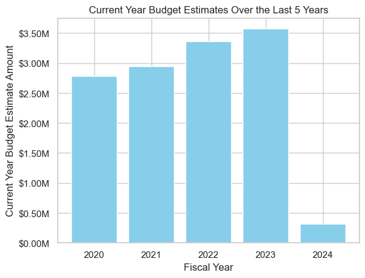

```python
#See how the Currrent Year Budget Estimates as changed over the last 5 years
# Set the style of seaborn
sns.set(style="whitegrid")
# Filter the data for the last 5 years
last_5_years = statement[statement['Fiscal Year'].between(statement['Fiscal Year'].max() - 4, statement['Fiscal Year'].max())]

# Group by 'Fiscal Year' and calculate the sum of 'Current Year Budget Estimate Amount' for each year
BudgetEstimate= last_5_years.groupby('Fiscal Year')['Current Year Budget Estimate Amount'].sum()

# Function to format y-axis labels as millions
def format_millions(value, _):
    return "${:.2f}M".format(value / 1e8)
# Formatting y-axis labels as billions
plt.gca().yaxis.set_major_formatter(FuncFormatter(format_millions))

# Plotting a bar chart
plt.bar(BudgetEstimate.index, BudgetEstimate.values, color='skyblue')
plt.xlabel('Fiscal Year')
plt.ylabel('Current Year Budget Estimate Amount')
plt.title('Current Year Budget Estimates Over the Last 5 Years')
plt.show()
plt.savefig('Current Year Budget Estimates Over the Last 5 Years.png')
```

Financial FYTD Receipt or Outlay Amount Visualization

This visualization displays the distribution and proportion of the spending over the last 5 years(2020-2024)

Insights: Visualization Details: The bar chart displays the fiscal year spending from 2020 to 2024. Visualization Insights: 2022 has the highest spending with over 1.75 trillion dollars.

Plot Details: X-Axis: Represents the 'Fiscal Year' which is from October- Septemeber of every year. Y-Axis: Displays 'FYTD Receipt or Outlay Amount' amounts in trillion. This means the amount of spending.

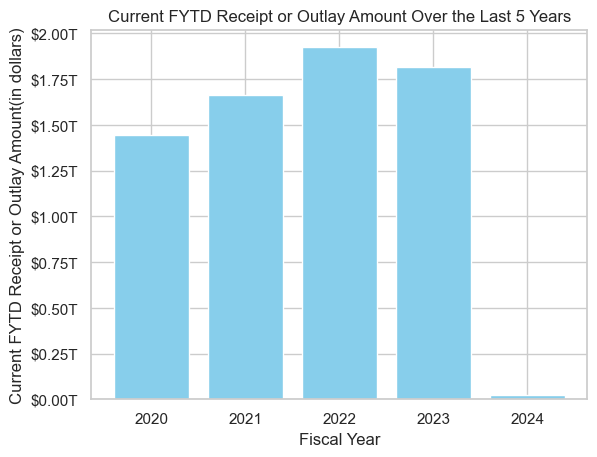

```python
#Current FYTD Receipt or Outlay Amount over the past 5 years

# Function to format y-axis labels as dollars
def format_trillions(value, _):
    return "${:.2f}T".format(value / 1e14)

# Filter the data for the last 5 years
last_5_years = statement[statement['Fiscal Year'].between(statement['Fiscal Year'].max() - 4, statement['Fiscal Year'].max())]

# Group by 'Fiscal Year' and calculate the sum of 'Current FYTD Receipt or Outlay Amount' for each year
FYTDReceipt= last_5_years.groupby('Fiscal Year')['Current FYTD Receipt or Outlay Amount'].sum()

# Plotting a bar chart
plt.bar(FYTDReceipt.index, FYTDReceipt.values, color='skyblue')

# Formatting y-axis labels as dollars
plt.gca().yaxis.set_major_formatter(FuncFormatter(format_trillions))

plt.xlabel('Fiscal Year')
plt.ylabel('Current FYTD Receipt or Outlay Amount(in dollars)')
plt.title('Current FYTD Receipt or Outlay Amount Over the Last 5 Years')
plt.show()
```

### A Closer Look at Three Sample Departments: Human and Health Services, Education, and Defense

```python
df = pd.read_csv("monthly_treasury_statement.csv",
                 na_values = {'Current Month Receipt or Outlay Amount': 0,
                             'Current FYTD Receipt or Outlay Amount': 0,
                             'Current Year Budget Estimate Amount': 0},
                 dtype = {'Classification Description': str}
                )
df['Record Date'] = pd.to_datetime(df['Record Date'])

# list of departments and agencies through which government spending takes place:
df["Classification Description"].unique()
```

```
array(['Budget Receipts', 'Individual Income Taxes',
       'Corporation Income Taxes',
       'Social Insurance and Retirement Receipts:',
       'Employment and General Retirement (Off-Budget)',
       'Employment and General Retirement (On-Budget)',
       'Unemployment Insurance', 'Other Retirement', 'Excise Taxes',
       'Estate and Gift Taxes', 'Customs Duties',
       'Miscellaneous Receipts', 'Total Receipts', '(On-Budget)',
       '(Off-Budget)', 'Budget Outlays', 'Legislative Branch',
       'Judicial Branch', 'Department of Agriculture',
       'Department of Commerce',
       'Department of Defense--Military Programs',
       'Department of Education', 'Department of Energy',
       'Department of Health and Human Services',
       'Department of Homeland Security',
       'Department of Housing and Urban Development',
       'Department of the Interior', 'Department of Justice',
       'Department of Labor', 'Department of State',
       'Department of Transportation', 'Department of the Treasury:',
       'Interest on Treasury Debt Securities (Gross)', 'Other',
       'Department of Veterans Affairs', 'Corps of Engineers',
       'Other Defense Civil Programs', 'Environmental Protection Agency',
       'Executive Office of the President',
       'General Services Administration',
       'International Assistance Programs',
       'National Aeronautics and Space Administration',
       'National Science Foundation', 'Office of Personnel Management',
       'Small Business Administration', 'Social Security Administration',
       'Independent Agencies', 'Allowances',
       'Undistributed Offsetting Receipts:', 'Interest', 'Total Outlays',
       'Surplus (+) or Deficit (-)',
       'Southwest Border Regional Commission',
       'Alyce Spotted Bear and Walter Soboleff Commission on Native Children',
       '400 Years of African-American History Commission',
       'National Security Commission on Artificial Intelligence',
       'Federal Permitting Improvement Steering Council'], dtype=object)
```

We are interested in the Department of Health and Human Services, the Department of Education and the Department of Defense, so we define them:

```python
defense_dept = df[df["Classification Description"].isin(["Department of Defense--Military Programs"])]
health_dept = df[df["Classification Description"].isin(["Department of Health and Human Services"])]
edu_dept = df[df["Classification Description"].isin(["Department of Education"])]

depts_of_interest = df[df["Classification Description"].isin(["Department of Defense--Military Programs", "Department of Health and Human Services", "Department of Homeland Security", "Department of Education"])]
```

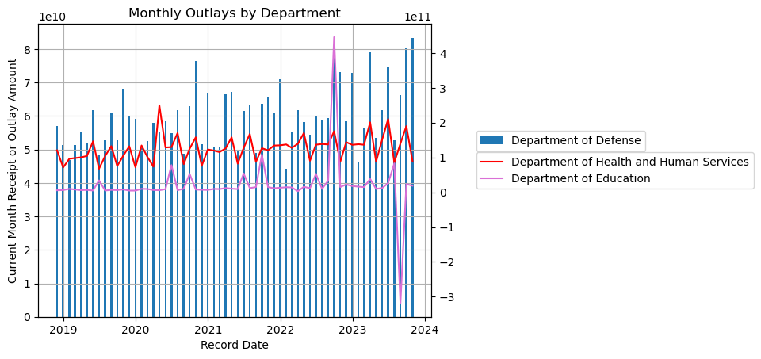

```python
plt.figure(figsize=(15, 10))

fig, ax = plt.subplots()
plt.grid(True)
ax.bar(defense_dept["Record Date"], defense_dept["Current Month Receipt or Outlay Amount"], width = 10, label='Department of Defense')

ax2 = ax.twinx()
ax2.plot(health_dept["Record Date"], health_dept["Current Month Receipt or Outlay Amount"], color='red', label='Department of Health and Human Services')
ax2.plot(edu_dept["Record Date"], edu_dept["Current Month Receipt or Outlay Amount"], color='orchid', label='Department of Education')

ax.set_xlabel('Record Date')
ax.set_ylabel('Current Month Receipt or Outlay Amount')
ax.set_title('Monthly Outlays by Department')

ax.legend(bbox_to_anchor=(1.1, 0.6), loc='center left')
ax2.legend(bbox_to_anchor=(1.1, 0.5), loc='center left')

plt.show()
```